# Installing Software and data for R workshop (more detailed version)

## 1. Installing R and RStudio

The first step is to install the R and RStudio applications:

- Download R @ The [R Project’s Home Page](https://cloud.r-project.org/)
  - Windows:
    - https://cloud.r-project.org/bin/windows/base/R-3.6.1-win.exe
  - Mac:
    - https://cloud.r-project.org/bin/macosx/R-3.6.1.pkg
  - Linux
    - https://cloud.r-project.org/bin/linux/
- Download RStudio Desktop from [RStudio](https://www.rstudio.com/products/rstudio/download/#download)
  - Windows
    - https://download1.rstudio.org/desktop/windows/RStudio-1.2.5019.exe
  - Mac
    - https://cloud.r-project.org/bin/macosx/R-3.6.1.pkg
  - Linux
    - https://www.rstudio.com/products/rstudio/download/#download
- Run the installers for R and RStudio, in that order.

If successful, you should be able to open RStudio and it looks like this.

[figure not shown]

### 1b. Trying it out

You can copy-paste this command into the window named **Console** and hit enter. There should be a plot resulting.

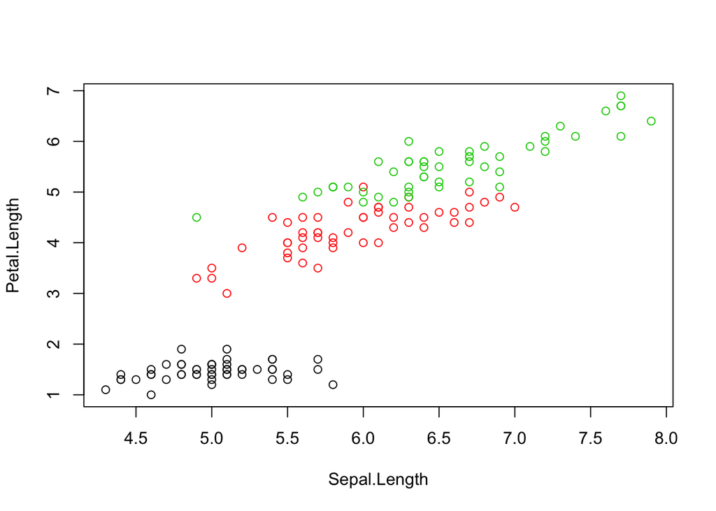

```r
plot(Petal.Length~Sepal.Length, data = iris, col = Species)
```

## 2. Installing some useful R packages

Now, run the following command to install a useful collection of packages (you can copy-paste the text below directly into the command prompt in R and hit enter):

```r
install.packages("tidyverse")
```

Here is a recording of the installation on my own computer. (**This installation may take a while**)

[video not shown]

The tidyverse is a collection of useful packages that add a lot of functionality to what is built-in to R. The two main packages we will use are:

- `dplyr`: for filtering, aggregating and summarising data
- `ggplot2`: for superior data visualisation

### 2b. Trying it out

You can verify the tidyverse installed by trying the following:

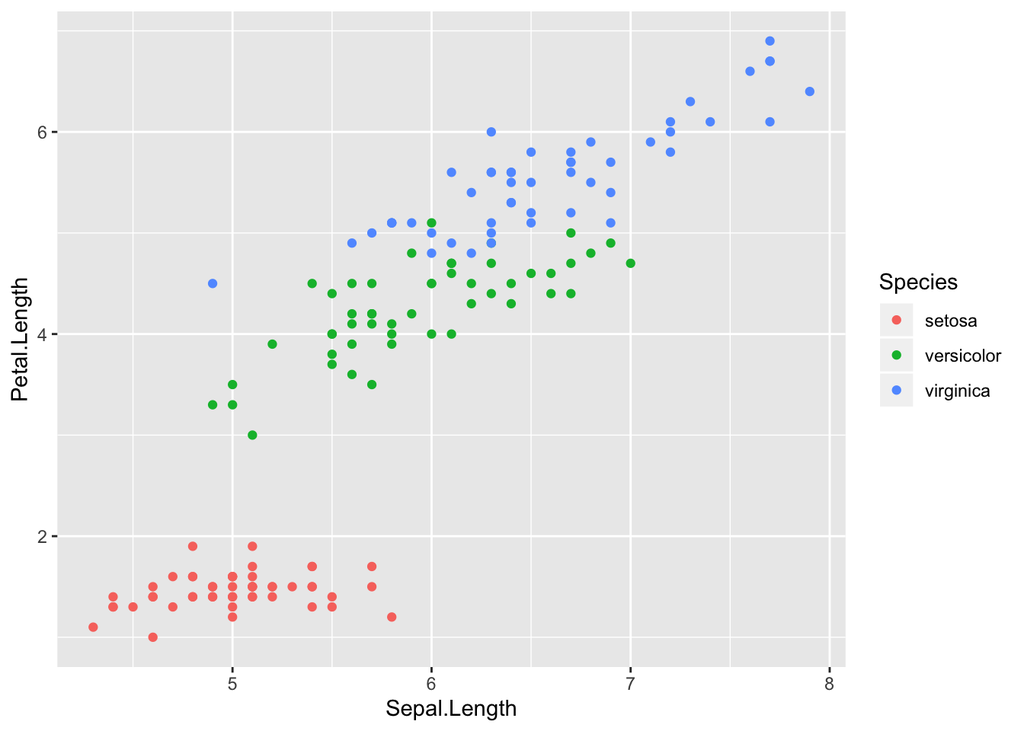

```r
library(ggplot2)
ggplot(data = iris, aes(x = Sepal.Length, y = Petal.Length, colour = Species)) +
  geom_point()
```

## 3. Getting data we will be using

Install the data we will be using:

```r
install.packages("devtools")
library(devtools)
install_github("thisisdaryn/workshop")
```

### 3b. Trying it out

```r
library(workshop)
head(lara)
```

| Runs | Inning | Notout | DNB | Opp | Ground | Start Date | Match |
| --- | --- | --- | --- | --- | --- | --- | --- |
| 11 | 1 | FALSE | FALSE | Pakistan | Karachi | 9-Nov-90 | ODI # 639 |
| 44 | 1 | FALSE | FALSE | Pakistan | Lahore | 6-Dec-90 | Test # 1158 |
| 5 | 2 | FALSE | FALSE | Pakistan | Lahore | 6-Dec-90 | Test # 1158 |
| 23 | 1 | FALSE | FALSE | England | Lord's | 27-May-91 | ODI # 678 |
| 5 | 1 | FALSE | FALSE | Pakistan | Sharjah | 17-Oct-91 | ODI # 679 |
| 45 | 1 | FALSE | FALSE | India | Sharjah | 19-Oct-91 | ODI # 681 |

### 3c There’s one remaining package with data that we may be using:

```r
install.packages("nycflights13")
```

- This data set contains flight information from 2013 for flights out of the 3 major airports in or near to New York City.
- You can verify you have the data using the following command

```r
library(nycflights13)
View(flights)
```

Let me know if anything didn’t go smoothly - Daryn